# Final Project - Module 8

Rtists

2022-12-03

## Introduction

Climate change may be having a detrimental impact on the conservation of the trans-Gulf migrant (TGM) population. TGMs are neotropical passerines that migrate from Central and South America to temperate latitudes during the northern hemisphere spring, flying non-stop over the Gulf of Mexico and arriving on land between Texas and Florida. TGMs make this journey in order to forage and breed in the temperate latitudes. According to Smith (2005) and Newton (2008), Evolutionary trade-offs are made depending on if the TGM arrives earlier and has an increased chance of finding a mate and breeding multiple times, or later and having an increased food availability. The dates that TGMs arrive at their destination has become of particular interest to researchers because of these consequences on fitness, and the way that climate change is influencing these arrival dates. According to Both (2006), spring temperatures are rising, and TGM populations may decline if they fail to shift their breeding site arrival dates accordingly. There is debate over if and how TGMs and other migrants shift their spring arrival in temperate North America in response to local temperature changes. A 2019 study, Horton (2019), did not find an overall change in the annual number of migrants between 2007 and 2015 or the annual timing of peak migration from 1995 to 2015; however, they did find that the earliest seasonal movements throughout the region occurred a significant 1.6 days per decade earlier. Also, according to Horton (2019), the study also found phenological changes over time; the most significant being the emergence of larger-bodies and shorter distance migrants. Despite this study, the topic of migration pattern changes in response to climate change is still hotly debated and needs to be researched further. In 2002, the Cornell Laboratory of Ornithology and the National Audubon Society launched eBird, the most popular and far-reaching online program through which amateur birders can submit bird observations. This data supplements what is collected through field, banding, and tracking studies, which are often temporally limited due to the small number of trained experts. This data aims to study the effects of changes in climate change linked local environment parameters on migration phenology. The data collected by eBird covers a wide range of taxonomy and geography. Thousands of amateur birders have contributed over 100 million bird observations to eBird, including historical observations that predate the launch of the program. We downloaded eBird’s species occurrence data from the Global Biodiversity Information Facility with an R package, rgif, that allows us to access the application programming interface. We also used an R package, rnoa, to interact with NOAA’s National Climate Data Center’s application programming interface in order to compile meteorological data. We used this eBird and meteorological data to study the effects of local weather conditions on the arrival times of TGMs in Massachusetts. We were investigating if local weather conditions that are related to climate change are impacting TGM arrival times, which has implications for fitness changes and species conservation.

## Results

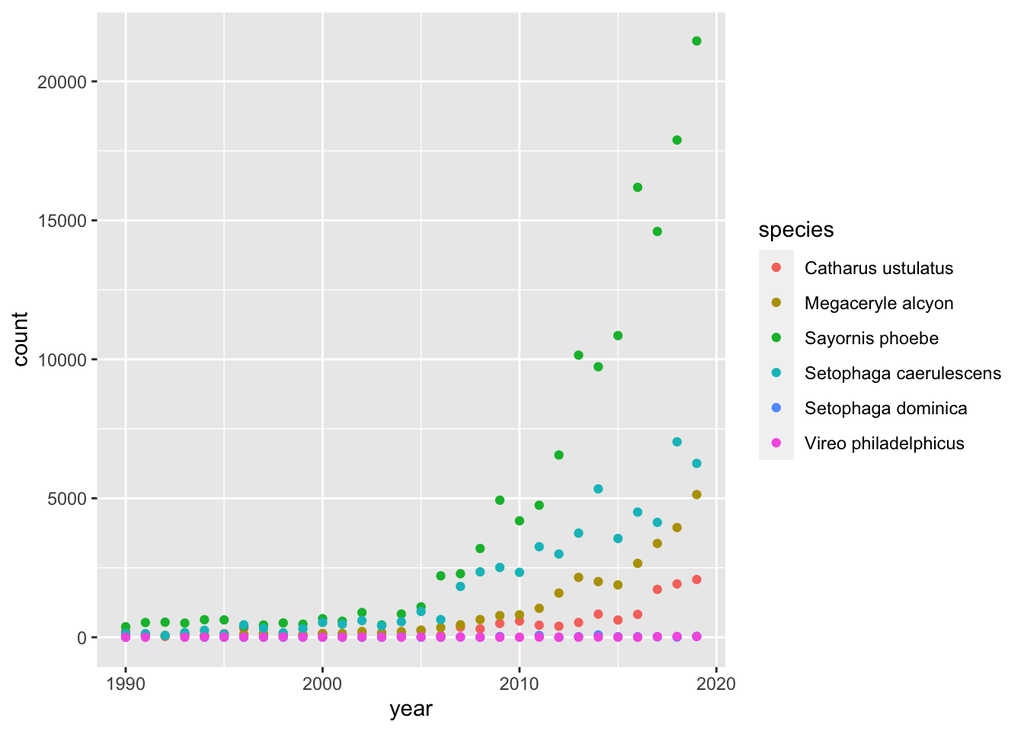

After loading in the species occurrence data from GBIF, this graph displays a general overview of the quantity of data points we have. It shows the count many species occurrence recordings there were per year.

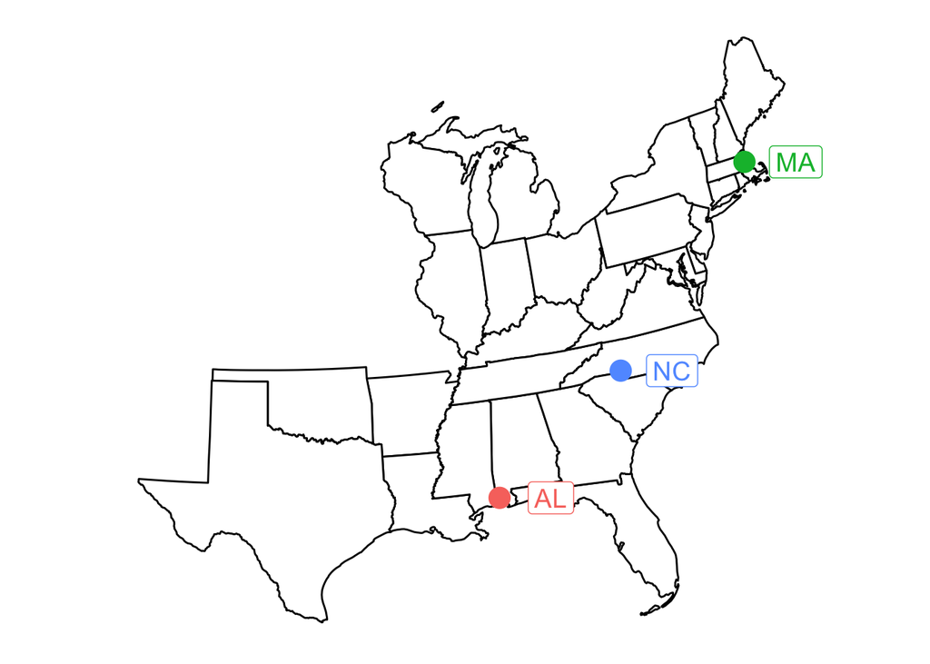

This map is a graphical representation of the locations of the 3 stations we are collecting weather data out of.

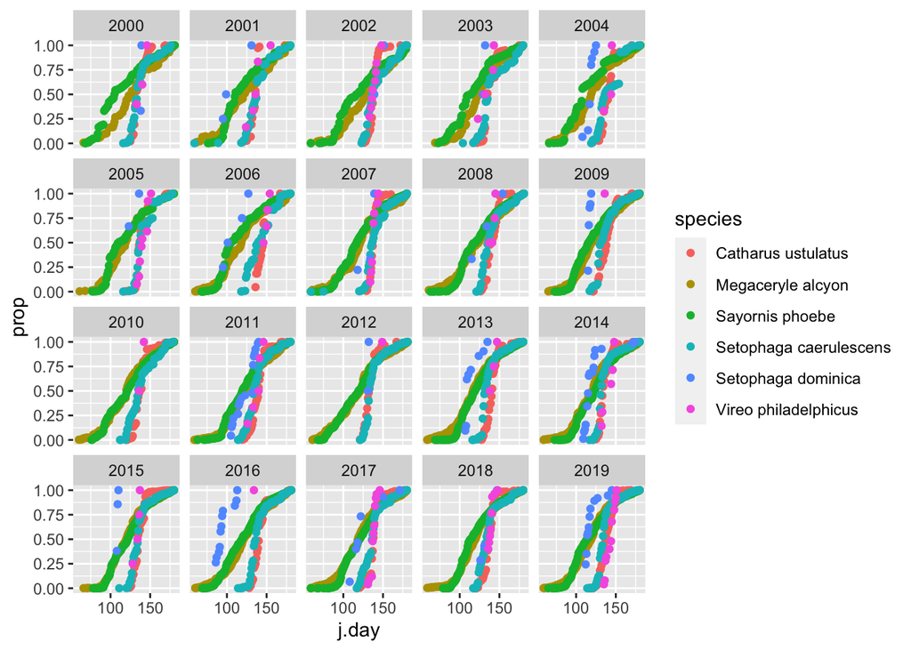

This is a graphical representation of the arrival of each species over the span of 2000-2019. Below, we divided this arrival data by species and created logistic models to model each species’ arrival data and estimate the arrival function.

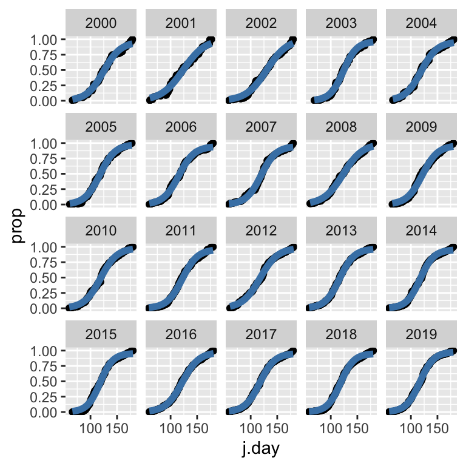

Belted Kingfisher

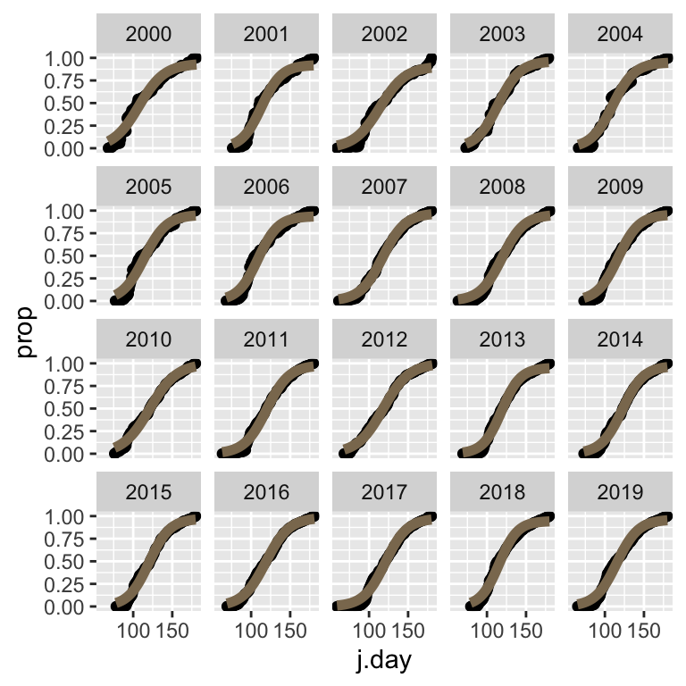

Eastern Phoebe

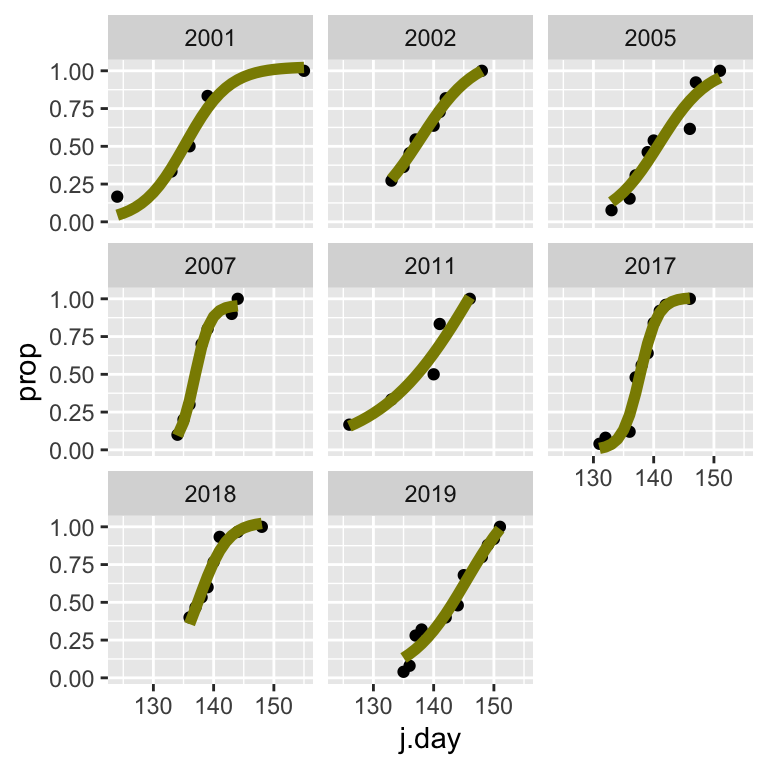

Philadelphia Vireo

There are fewer years than the other species for the Philadelphia Vireo. This is due to the fact that there were too few occurrence data points for the omitted years to base a logistic curve off of. This is prevalent in a few other species as well.

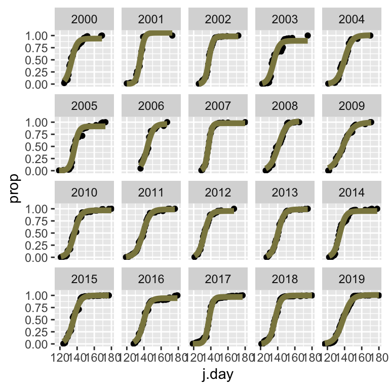

Swainson’s Thrush

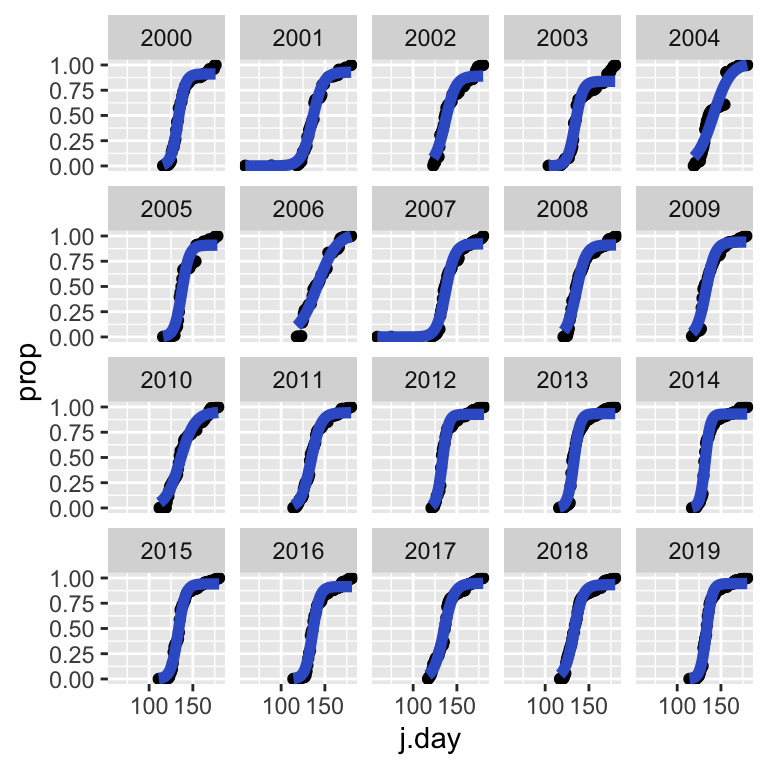

Black-Throated Blue Warbler

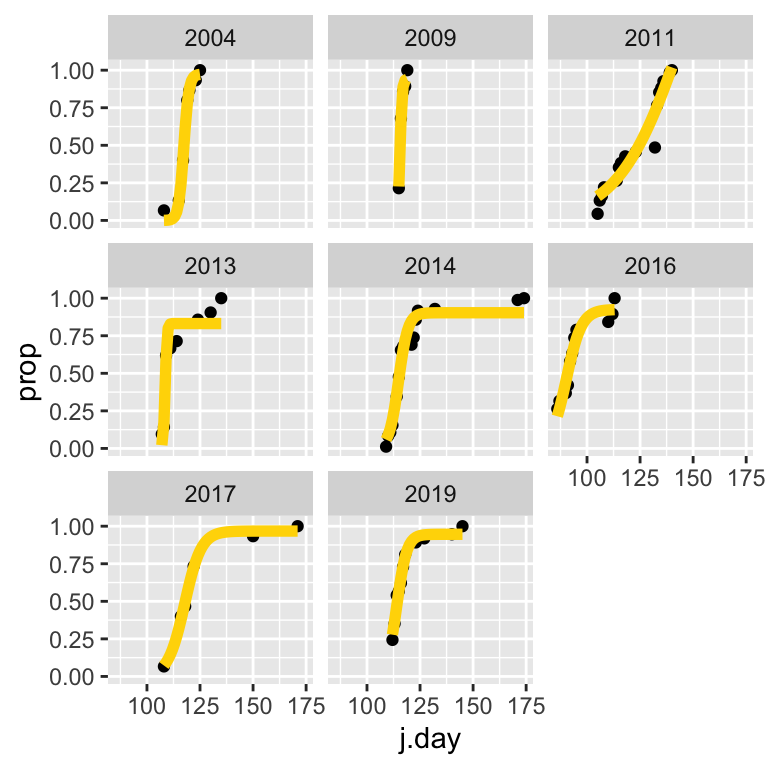

Yellow-Throated Warbler

From all of the species logistic models, it appears each species arrives at staggered points in the year. The next analysis will determine if these arrival dates fluctuate year to year, or if they are relatively consistent.

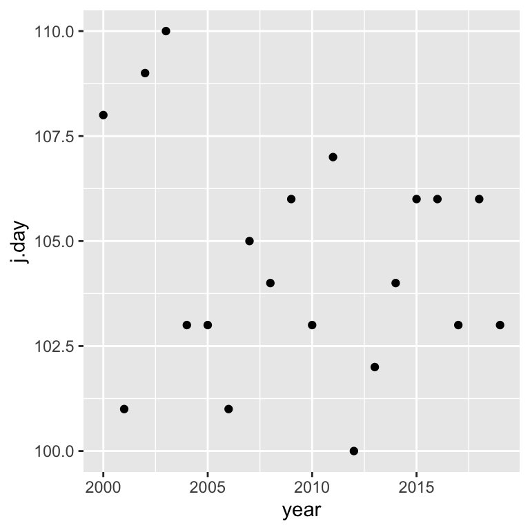

Belted Kingfisher

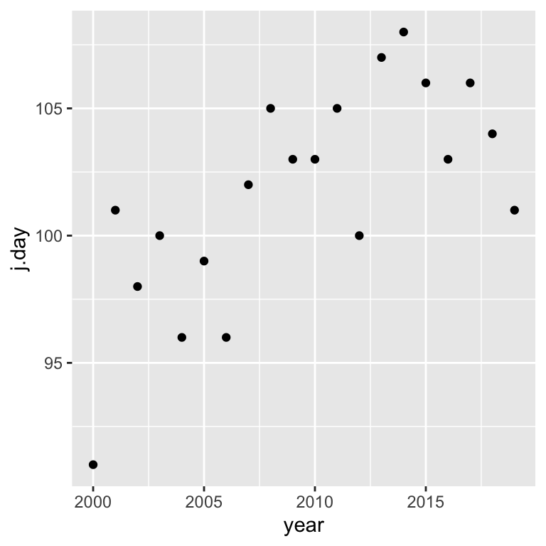

Eastern Phoebe

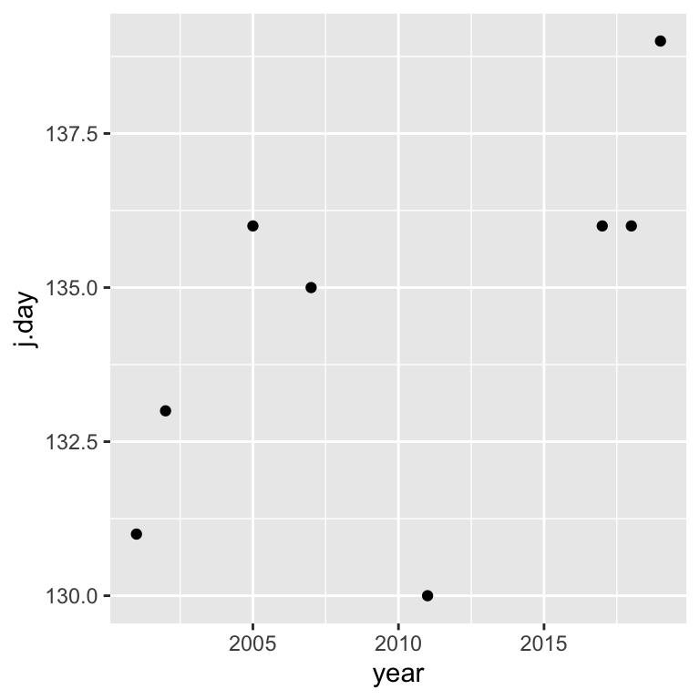

Philadelphia Vireo

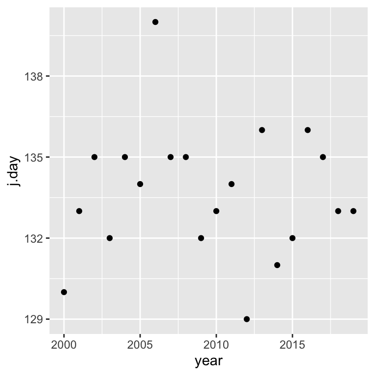

Swainson’s Thrush

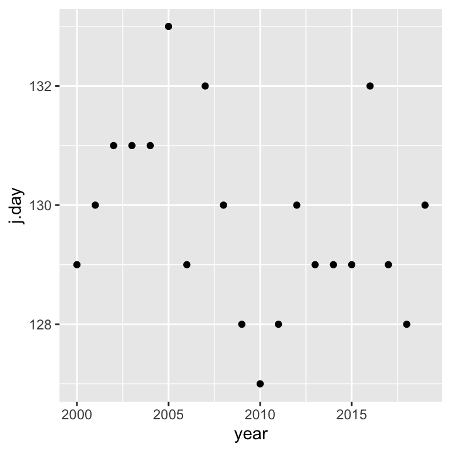

Black-Throated Blue Warbler

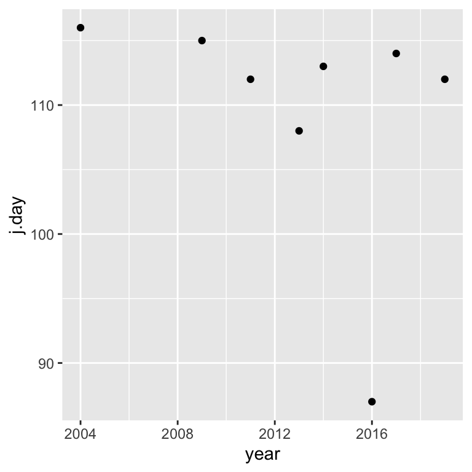

Yellow-Throated Warbler

These results insinuate that there is relative inconsistency among arrival date from year to year, for each species. We will conduct further analysis with weather data from the migration path to see if weather has an effect on these species’ arrival dates on an annual basis.

### Linear Models

Belted Kingfisher

|  | Chisq | Df | Pr(>Chisq) |
| --- | --- | --- | --- |
| tmin | 0.3743636 | 1 | 0.5406353 |
| tmax | 0.2096010 | 1 | 0.6470803 |
| wvec | 2.1552017 | 1 | 0.1420878 |
| tmin:tmax | 0.2974615 | 1 | 0.5854782 |
| tmin:wvec | 0.2682919 | 1 | 0.6044799 |
| tmax:wvec | 0.8880453 | 1 | 0.3460076 |
| tmin:tmax:wvec | 0.3627751 | 1 | 0.5469690 |

Eastern Phoebe

|  | Chisq | Df | Pr(>Chisq) |
| --- | --- | --- | --- |
| tmin | 0.7322408 | 1 | 0.3921578 |
| tmax | 0.1707551 | 1 | 0.6794416 |
| wvec | 0.0035386 | 1 | 0.9525646 |
| tmin:tmax | 0.0358576 | 1 | 0.8498098 |
| tmin:wvec | 0.9804517 | 1 | 0.3220873 |
| tmax:wvec | 0.7977705 | 1 | 0.3717608 |
| tmin:tmax:wvec | 0.7359299 | 1 | 0.3909678 |

Philadelphia Vireo

|  | Chisq | Df | Pr(>Chisq) |
| --- | --- | --- | --- |
| tmin | 0.0122180 | 1 | 0.9119851 |
| tmax | 0.0747970 | 1 | 0.7844762 |
| wvec | 0.4013030 | 1 | 0.5264171 |
| tmin:tmax | 0.0036993 | 1 | 0.9515009 |
| tmin:wvec | 0.0019720 | 1 | 0.9645796 |
| tmax:wvec | 0.0800114 | 1 | 0.7772819 |
| tmin:tmax:wvec | 0.3093496 | 1 | 0.5780796 |

Swainson’s Thrush

|  | Chisq | Df | Pr(>Chisq) |
| --- | --- | --- | --- |
| tmin | 2.9325613 | 1 | 0.0868097 |
| tmax | 1.5503533 | 1 | 0.2130833 |
| wvec | 2.2993483 | 1 | 0.1294283 |
| tmin:tmax | 0.0167344 | 1 | 0.8970716 |
| tmin:wvec | 0.0060418 | 1 | 0.9380437 |
| tmax:wvec | 0.1019241 | 1 | 0.7495327 |
| tmin:tmax:wvec | 2.8604597 | 1 | 0.0907816 |

Black Throated Blue Warbler

|  | Chisq | Df | Pr(>Chisq) |
| --- | --- | --- | --- |
| tmin | 0.1789512 | 1 | 0.6722761 |
| tmax | 0.1077769 | 1 | 0.7426895 |
| wvec | 1.2640396 | 1 | 0.2608878 |
| tmin:tmax | 2.7954787 | 1 | 0.0945305 |
| tmin:wvec | 0.0257459 | 1 | 0.8725226 |
| tmax:wvec | 0.4174290 | 1 | 0.5182227 |
| tmin:tmax:wvec | 0.8265158 | 1 | 0.3632820 |

Yellow-Throated Warbler

|  | Chisq | Df | Pr(>Chisq) |
| --- | --- | --- | --- |
| tmin | 0.4044594 | 1 | 0.5247952 |
| tmax | 2.1677270 | 1 | 0.1409344 |
| wvec | 0.8606517 | 1 | 0.3535564 |
| tmin:tmax | 0.3582425 | 1 | 0.5494839 |
| tmin:wvec | 0.0007349 | 1 | 0.9783723 |
| tmax:wvec | 0.0860943 | 1 | 0.7692025 |
| tmin:tmax:wvec | 0.5292749 | 1 | 0.4669119 |

Due to the nature of our complex data set, we performed linear mixed-effect modeling, as there are some variables (such as the weather variables of temperature and the wind vector) that are fixed, meaning they contribute to the slope and intercept of model but do not change among all of the samples we have; i.e. the weather is the same for each bird species. There are random effect variables, like the location of the station and the species, which we also have to take into consideration when we create models to better understand trends in our data. The first linear model assessed used weather data from a single-day report from the weather station to assess the relationship of those fixed weather variables with the arrival date (j.day), with a random effect of the station location. The weather variables assessed are maximum temperature of the area (tmax), minimum temperature of the area (tmin), and then a wind vector value. We calculated using average wind velocity in meters per second and the direction of the fastest 2-minute wind. We performed ANOVA tests to see how the linear model created fits the data. The ANOVA test results indicate using only single-day weather data at each location doesn’t reveal any significant relationships between weather and arrival day.

Belted Kingfisher

|  | Chisq | Df | Pr(>Chisq) |
| --- | --- | --- | --- |
| wk.tmin | 0.3012525 | 1 | 0.5830983 |
| wk.tmax | 1.0577126 | 1 | 0.3037375 |
| wk.wvec | 5.8422155 | 1 | 0.0156461 |
| wk.tmin:wk.tmax | 0.7963862 | 1 | 0.3721760 |
| wk.tmin:wk.wvec | 0.2039524 | 1 | 0.6515493 |
| wk.tmax:wk.wvec | 0.1703423 | 1 | 0.6798078 |
| wk.tmin:wk.tmax:wk.wvec | 3.4342078 | 1 | 0.0638592 |

Eastern Phoebe

|  | Chisq | Df | Pr(>Chisq) |
| --- | --- | --- | --- |
| wk.tmin | 0.5743397 | 1 | 0.4485396 |
| wk.tmax | 1.8430251 | 1 | 0.1745968 |
| wk.wvec | 7.7486487 | 1 | 0.0053753 |
| wk.tmin:wk.tmax | 1.4650357 | 1 | 0.2261306 |
| wk.tmin:wk.wvec | 2.1928507 | 1 | 0.1386525 |
| wk.tmax:wk.wvec | 3.3214389 | 1 | 0.0683820 |
| wk.tmin:wk.tmax:wk.wvec | 0.0000012 | 1 | 0.9991393 |

Philadelphia Vireo

|  | Chisq | Df | Pr(>Chisq) |
| --- | --- | --- | --- |
| wk.tmin | 2.2932079 | 1 | 0.1299411 |
| wk.tmax | 1.8770429 | 1 | 0.1706706 |
| wk.wvec | 2.3045478 | 1 | 0.1289958 |
| wk.tmin:wk.tmax | 0.1262882 | 1 | 0.7223121 |
| wk.tmin:wk.wvec | 1.7728802 | 1 | 0.1830260 |
| wk.tmax:wk.wvec | 0.4884092 | 1 | 0.4846378 |
| wk.tmin:wk.tmax:wk.wvec | 1.6333989 | 1 | 0.2012336 |

Swainson’s Thrush

|  | Chisq | Df | Pr(>Chisq) |
| --- | --- | --- | --- |
| wk.tmin | 2.3141074 | 1 | 0.1282049 |
| wk.tmax | 1.4486675 | 1 | 0.2287419 |
| wk.wvec | 2.6146787 | 1 | 0.1058790 |
| wk.tmin:wk.tmax | 4.9354684 | 1 | 0.0263109 |
| wk.tmin:wk.wvec | 0.3936106 | 1 | 0.5304076 |
| wk.tmax:wk.wvec | 1.1033100 | 1 | 0.2935408 |
| wk.tmin:wk.tmax:wk.wvec | 0.3358604 | 1 | 0.5622285 |

Black-Throated Blue Warbler

|  | Chisq | Df | Pr(>Chisq) |
| --- | --- | --- | --- |
| wk.tmin | 0.6105100 | 1 | 0.4345959 |
| wk.tmax | 0.0113558 | 1 | 0.9151352 |
| wk.wvec | 4.6702108 | 1 | 0.0306902 |
| wk.tmin:wk.tmax | 3.3868135 | 1 | 0.0657198 |
| wk.tmin:wk.wvec | 0.2274892 | 1 | 0.6333918 |
| wk.tmax:wk.wvec | 0.6006283 | 1 | 0.4383384 |
| wk.tmin:wk.tmax:wk.wvec | 1.2031676 | 1 | 0.2726895 |

Yellow-Throated Warbler

|  | Chisq | Df | Pr(>Chisq) |
| --- | --- | --- | --- |
| wk.tmin | 0.5207085 | 1 | 0.4705396 |
| wk.tmax | 0.0081352 | 1 | 0.9281322 |
| wk.wvec | 0.5210627 | 1 | 0.4703887 |
| wk.tmin:wk.tmax | 0.3403979 | 1 | 0.5595996 |
| wk.tmin:wk.wvec | 2.8760272 | 1 | 0.0899076 |
| wk.tmax:wk.wvec | 0.1345241 | 1 | 0.7137867 |
| wk.tmin:wk.tmax:wk.wvec | 5.0689279 | 1 | 0.0243584 |

### Secondary Model with Single-Day Weather data variables

Fit values for nested models of the most complicated lme model for Belted Kingfisher

|  | (Intercept) | tmax | tmin | wvec | tmax:tmin | tmax:wvec | tmin:wvec | tmax:tmin:wvec | df | logLik | AICc | delta | weight |
| --- | --- | --- | --- | --- | --- | --- | --- | --- | --- | --- | --- | --- | --- |
| 1 | 104.3981 | 0.0038097 | -0.0067756 | -0.0156179 | NA | NA | NA | NA | 6 | -153.8843 | 321.3535 | 0.00000 | 0.9995442696 |
| 5 | 104.5273 | 0.0036942 | -0.0088318 | -0.0239836 | NA | NA | 0.0001185 | NA | 7 | -161.1839 | 338.5216 | 17.16814 | 0.0001869769 |
| 3 | 104.3493 | 0.0039858 | -0.0060024 | -0.0024601 | NA | -6.89e-05 | NA | NA | 7 | -161.4548 | 339.0635 | 17.71005 | 0.0001425977 |
| 2 | 105.8820 | -0.0023184 | -0.0313929 | -0.0160617 | 9.69e-05 | NA | NA | NA | 7 | -161.5774 | 339.3086 | 17.95507 | 0.0001261558 |

Fit values for nested models of the most complicated lme model for Eastern Phoebe

|  | (Intercept) | tmax | tmin | wvec | tmax:tmin | tmax:wvec | tmin:wvec | tmax:tmin:wvec | df | logLik | AICc | delta | weight |
| --- | --- | --- | --- | --- | --- | --- | --- | --- | --- | --- | --- | --- | --- |
| 1 | 101.8385 | -0.0060002 | 0.0134304 | -0.0012943 | NA | NA | NA | NA | 6 | -179.8811 | 373.3470 | 0.00000 | 0.9993290711 |
| 5 | 101.9129 | -0.0055441 | 0.0100207 | -0.0136598 | NA | NA | 0.0001815 | NA | 7 | -186.6448 | 389.4435 | 16.09644 | 0.0003194554 |
| 3 | 101.8538 | -0.0064612 | 0.0150297 | 0.0141491 | NA | -8.31e-05 | NA | NA | 7 | -186.9778 | 390.1095 | 16.76245 | 0.0002289752 |
| 2 | 101.8111 | -0.0058716 | 0.0141357 | -0.0012467 | -3e-06 | NA | NA | NA | 7 | -187.6033 | 391.3605 | 18.01349 | 0.0001224982 |

Fit values for nested models of the most complicated lme model for Philadelphia Vireo

|  | (Intercept) | tmax | tmin | wvec | tmax:tmin | tmax:wvec | tmin:wvec | tmax:tmin:wvec | df | logLik | AICc | delta | weight |
| --- | --- | --- | --- | --- | --- | --- | --- | --- | --- | --- | --- | --- | --- |
| 1 | 133.0673 | 0.0100419 | -0.0104240 | 0.0186196 | NA | NA | NA | NA | 6 | -66.86939 | 150.6800 | 0.00000 | 0.9993646015 |
| 5 | 132.6812 | 0.0057459 | 0.0025825 | 0.0746257 | NA | NA | -0.0004454 | NA | 7 | -72.96595 | 166.9319 | 16.25194 | 0.0002955696 |
| 3 | 132.8770 | 0.0080627 | -0.0031641 | 0.0972712 | NA | -0.0003249 | NA | NA | 7 | -73.34619 | 167.6924 | 17.01241 | 0.0002020809 |
| 2 | 130.0247 | 0.0215948 | 0.0189802 | 0.0207836 | -0.0001066 | NA | NA | NA | 7 | -73.72943 | 168.4589 | 17.77890 | 0.0001377480 |

Fit values for nested models of the most complicated lme model for Swainson’s Thrush

|  | (Intercept) | tmax | tmin | wvec | tmax:tmin | tmax:wvec | tmin:wvec | tmax:tmin:wvec | df | logLik | AICc | delta | weight |
| --- | --- | --- | --- | --- | --- | --- | --- | --- | --- | --- | --- | --- | --- |
| 1 | 133.6500 | 0.0090659 | -0.0179345 | -0.0192076 | NA | NA | NA | NA | 6 | -145.6766 | 304.9381 | 0.00000 | 0.9994115949 |
| 5 | 133.5398 | 0.0101208 | -0.0194735 | -0.0374896 | NA | NA | 0.0001521 | NA | 7 | -152.6150 | 321.3839 | 16.44581 | 0.0002682763 |
| 3 | 133.3166 | 0.0106875 | -0.0189428 | -0.0519214 | NA | 0.0001362 | NA | NA | 7 | -152.9420 | 322.0379 | 17.09981 | 0.0001934496 |
| 2 | 135.2860 | 0.0029009 | -0.0355800 | -0.0190463 | 6.47e-05 | NA | NA | NA | 7 | -153.3654 | 322.8847 | 17.94653 | 0.0001266792 |

Fit values for nested models of the most complicated lme model for Black-Throated Blue Warbler

|  | (Intercept) | tmax | tmin | wvec | tmax:tmin | tmax:wvec | tmin:wvec | tmax:tmin:wvec | df | logLik | AICc | delta | weight |
| --- | --- | --- | --- | --- | --- | --- | --- | --- | --- | --- | --- | --- | --- |
| 1 | 128.9145 | 0.0019995 | 0.0028669 | -0.0078675 | NA | NA | NA | NA | 6 | -122.7852 | 259.1554 | 0.00000 | 9.995644e-01 |
| 2 | 133.3536 | -0.0151838 | -0.0412628 | -0.0081646 | 0.0001664 | NA | NA | NA | 7 | -129.9382 | 276.0302 | 16.87480 | 2.165188e-04 |
| 5 | 128.9072 | 0.0017161 | 0.0035519 | -0.0046042 | NA | NA | -2.56e-05 | NA | 7 | -130.4167 | 276.9873 | 17.83192 | 1.341712e-04 |
| 3 | 128.9261 | 0.0019128 | 0.0030291 | -0.0039362 | NA | -1.71e-05 | NA | NA | 7 | -130.8742 | 277.9022 | 18.74678 | 8.491788e-05 |

Fit values for nested models of the most complicated lme model for Yellow-Throated Warbler

|  | (Intercept) | tmax | tmin | wvec | tmax:tmin | tmax:wvec | tmin:wvec | tmax:tmin:wvec | df | logLik | AICc | delta | weight |
| --- | --- | --- | --- | --- | --- | --- | --- | --- | --- | --- | --- | --- | --- |
| 1 | 100.9383 | 0.0562784 | -0.0303479 | -0.0399679 | NA | NA | NA | NA | 6 | -90.49218 | 197.9255 | 0.00000 | 0.9988129623 |
| 5 | 101.3088 | 0.0657923 | -0.0573819 | -0.1201088 | NA | NA | 0.0007347 | NA | 7 | -96.17386 | 213.3477 | 15.42219 | 0.0004472985 |
| 2 | 111.8998 | 0.0123494 | -0.2127958 | -0.0559252 | 0.0007178 | NA | NA | NA | 7 | -96.24465 | 213.4893 | 15.56376 | 0.0004167311 |
| 3 | 100.4815 | 0.0600622 | -0.0387760 | -0.1121913 | NA | 0.0003515 | NA | NA | 7 | -96.49941 | 213.9988 | 16.07329 | 0.0003230082 |

We utilized another method to find a best fit model, where we used the dredge function to assess only the three weather variables: tmin, tmax, and wvec, and their varying combinations of interactions. The data tables above indicate the best fitting models with the 3 weather variables as fixed effects. From these tables, we can surmise that the best fitting models, for each species, contain all three variables to have an effect on arrival date.

### Secondary Model with Average weather data variables

Fit values for nested models of the most complicated lme model for Belted Kingfisher

|  | (Intercept) | wk.tmax | wk.tmin | wk.wvec | wk.tmax:wk.tmin | wk.tmax:wk.wvec | wk.tmin:wk.wvec | wk.tmax:wk.tmin:wk.wvec | df | logLik | AICc | delta | weight |
| --- | --- | --- | --- | --- | --- | --- | --- | --- | --- | --- | --- | --- | --- |
| 1 | 105.8466 | -0.0112605 | 0.0069239 | 0.0827719 | NA | NA | NA | NA | 6 | -150.8651 | 315.3152 | 0.00000 | 0.9979619062 |
| 5 | 106.1712 | -0.0178362 | 0.0218917 | 0.1426720 | NA | NA | -0.0009247 | NA | 7 | -156.4246 | 329.0030 | 13.68776 | 0.0010637879 |
| 3 | 106.0485 | -0.0142345 | 0.0134931 | 0.1466969 | NA | -0.0003775 | NA | NA | 7 | -157.1056 | 330.3651 | 15.04993 | 0.0005383493 |
| 2 | 103.8176 | -0.0095587 | 0.1013335 | 0.0947336 | -0.0003376 | NA | NA | NA | 7 | -157.3166 | 330.7871 | 15.47186 | 0.0004359567 |

Fit values for nested models of the most complicated lme model for Eastern Phoebe

|  | (Intercept) | wk.tmax | wk.tmin | wk.wvec | wk.tmax:wk.tmin | wk.tmax:wk.wvec | wk.tmin:wk.wvec | wk.tmax:wk.tmin:wk.wvec | df | logLik | AICc | delta | weight |
| --- | --- | --- | --- | --- | --- | --- | --- | --- | --- | --- | --- | --- | --- |
| 1 | 103.6517 | -0.028779 | 0.0387302 | 0.1437472 | NA | NA | NA | NA | 6 | -173.5211 | 360.6271 | 0.00000 | 0.9974653536 |
| 5 | 104.0377 | -0.035772 | 0.0543455 | 0.1932277 | NA | NA | -0.0007976 | NA | 7 | -178.9745 | 374.1028 | 13.47577 | 0.0011821489 |
| 2 | 101.1013 | -0.027515 | 0.1753628 | 0.1606590 | -0.0004947 | NA | NA | NA | 7 | -179.5093 | 375.1724 | 14.54532 | 0.0006925034 |
| 3 | 103.4911 | -0.025498 | 0.0308795 | 0.0968333 | NA | 0.0002867 | NA | NA | 7 | -179.5574 | 375.2686 | 14.64148 | 0.0006599941 |

Fit values for nested models of the most complicated lme model for Philadelphia Vireo

|  | (Intercept) | wk.tmax | wk.tmin | wk.wvec | wk.tmax:wk.tmin | wk.tmax:wk.wvec | wk.tmin:wk.wvec | wk.tmax:wk.tmin:wk.wvec | df | logLik | AICc | delta | weight |
| --- | --- | --- | --- | --- | --- | --- | --- | --- | --- | --- | --- | --- | --- |
| 1 | 133.0684 | -0.0221200 | 0.0590982 | -0.0936642 | NA | NA | NA | NA | 6 | -64.48711 | 145.9154 | 0.00000 | 0.9981273264 |
| 5 | 132.3657 | -0.0406744 | 0.1061984 | 0.1505653 | NA | NA | -0.0020684 | NA | 7 | -69.21933 | 159.4387 | 13.52326 | 0.0011551744 |
| 3 | 133.2992 | -0.0283103 | 0.0713198 | 0.0975192 | NA | -0.0007849 | NA | NA | 7 | -70.10809 | 161.2162 | 15.30079 | 0.0004749649 |
| 2 | 126.9912 | -0.0040859 | 0.1329213 | -0.0988765 | -0.0002386 | NA | NA | NA | 7 | -70.78019 | 162.5604 | 16.64499 | 0.0002425343 |

Fit values for nested models of the most complicated lme model for Swainson’s Thrush

|  | (Intercept) | wk.tmax | wk.tmin | wk.wvec | wk.tmax:wk.tmin | wk.tmax:wk.wvec | wk.tmin:wk.wvec | wk.tmax:wk.tmin:wk.wvec | df | logLik | AICc | delta | weight |
| --- | --- | --- | --- | --- | --- | --- | --- | --- | --- | --- | --- | --- | --- |
| 1 | 133.1904 | -0.0262669 | 0.0578187 | -0.0637370 | NA | NA | NA | NA | 6 | -143.1252 | 299.8353 | 0.00000 | 0.9941692160 |
| 3 | 133.6217 | -0.0182632 | 0.0354991 | -0.3830145 | NA | 0.0013803 | NA | NA | 7 | -147.5709 | 311.2957 | 11.46038 | 0.0032275235 |
| 5 | 133.8168 | -0.0168839 | 0.0316758 | -0.2432020 | NA | NA | 0.001522 | NA | 7 | -148.0096 | 312.1730 | 12.33770 | 0.0020814377 |
| 2 | 122.8178 | 0.0093818 | 0.1836513 | -0.0559196 | -0.0004496 | NA | NA | NA | 7 | -149.3931 | 314.9400 | 15.10467 | 0.0005218228 |

Fit values for nested models of the most complicated lme model for Black-Throated Blue Warbler

|  | (Intercept) | wk.tmax | wk.tmin | wk.wvec | wk.tmax:wk.tmin | wk.tmax:wk.wvec | wk.tmin:wk.wvec | wk.tmax:wk.tmin:wk.wvec | df | logLik | AICc | delta | weight |
| --- | --- | --- | --- | --- | --- | --- | --- | --- | --- | --- | --- | --- | --- |
| 1 | 129.2966 | -0.0039854 | 0.0137807 | -0.0443123 | NA | NA | NA | NA | 6 | -119.3864 | 252.3577 | 0.00000 | 0.9976201321 |
| 2 | 140.7746 | -0.0419607 | -0.1343694 | -0.0488581 | 0.0005203 | NA | NA | NA | 7 | -124.6778 | 265.5095 | 13.15175 | 0.0013902708 |
| 5 | 129.5296 | -0.0010143 | 0.0047788 | -0.1059027 | NA | NA | 0.000557 | NA | 7 | -125.3998 | 266.9535 | 14.59579 | 0.0006753507 |
| 3 | 129.3351 | -0.0035386 | 0.0123099 | -0.0646151 | NA | 9.21e-05 | NA | NA | 7 | -126.1649 | 268.4836 | 16.12590 | 0.0003142464 |

Fit values for nested models of the most complicated lme model for Yellow-Throated Warbler

|  | (Intercept) | wk.tmax | wk.tmin | wk.wvec | wk.tmax:wk.tmin | wk.tmax:wk.wvec | wk.tmin:wk.wvec | wk.tmax:wk.tmin:wk.wvec | df | logLik | AICc | delta | weight |
| --- | --- | --- | --- | --- | --- | --- | --- | --- | --- | --- | --- | --- | --- |
| 1 | 98.10707 | 0.1194743 | -0.1499143 | 0.0317171 | NA | NA | NA | NA | 6 | -87.70416 | 192.3495 | 0.000000 | 0.824857725 |
| 5 | 100.42946 | 0.0063245 | 0.1541558 | 0.9324723 | NA | NA | -0.014581 | NA | 7 | -87.43046 | 195.8609 | 3.511425 | 0.142522287 |
| 3 | 95.43157 | 0.1204736 | -0.0716078 | 1.2950323 | NA | -0.0075867 | NA | NA | 7 | -88.98004 | 198.9601 | 6.610591 | 0.030262677 |
| 2 | 57.58478 | 0.2972304 | 0.5203404 | -0.1629551 | -0.0027588 | NA | NA | NA | 7 | -91.53243 | 204.0649 | 11.715378 | 0.002357311 |

Similar to the secondary model utilizing single-day weather data variables, this model represents the best-fitting models using the 2-week average analysis weather variables. The data tables above indicate the best fitting models with the 3 weather variables as fixed effects. From these tables, we can surmise that the best fitting models, for each species, reflect all three variables having an effect on arrival date.

### Best fitting models

Belted Kingfisher

|  | Chisq | Df | Pr(>Chisq) |
| --- | --- | --- | --- |
| tmin | 0.5240737 | 1 | 0.4691091 |
| tmax | 0.2327380 | 1 | 0.6295010 |
| wvec | 2.1340652 | 1 | 0.1440583 |

Eastern Phoebe

|  | Chisq | Df | Pr(>Chisq) |
| --- | --- | --- | --- |
| tmin | 0.6965421 | 1 | 0.4039480 |
| tmax | 0.2095445 | 1 | 0.6471247 |
| wvec | 0.0040475 | 1 | 0.9492727 |

Philadelphia Vireo

|  | Chisq | Df | Pr(>Chisq) |
| --- | --- | --- | --- |
| tmin | 0.1929465 | 1 | 0.6604755 |
| tmax | 0.3188801 | 1 | 0.5722814 |
| wvec | 0.4165533 | 1 | 0.5186619 |

Swainson’s Thrush

|  | Chisq | Df | Pr(>Chisq) |
| --- | --- | --- | --- |
| tmin | 2.735115 | 1 | 0.0981644 |
| tmax | 1.388148 | 1 | 0.2387181 |
| wvec | 2.374487 | 1 | 0.1233322 |

Black-Throated Blue Warbler

|  | Chisq | Df | Pr(>Chisq) |
| --- | --- | --- | --- |
| tmin | 0.1655737 | 1 | 0.6840760 |
| tmax | 0.1763704 | 1 | 0.6745112 |
| wvec | 1.1822819 | 1 | 0.2768919 |

Yellow-Throated Warbler

|  | Chisq | Df | Pr(>Chisq) |
| --- | --- | --- | --- |
| tmin | 0.3345371 | 1 | 0.5629996 |
| tmax | 2.0596597 | 1 | 0.1512439 |
| wvec | 0.5911197 | 1 | 0.4419865 |

### Best fitting models – average weather data

Belted Kingfisher

|  | Chisq | Df | Pr(>Chisq) |
| --- | --- | --- | --- |
| wk.tmin | 0.0978688 | 1 | 0.7544023 |
| wk.tmax | 0.4926055 | 1 | 0.4827673 |
| wk.wvec | 4.5619552 | 1 | 0.0326897 |

Eastern Phoebe

|  | Chisq | Df | Pr(>Chisq) |
| --- | --- | --- | --- |
| wk.tmin | 1.239351 | 1 | 0.2655963 |
| wk.tmax | 1.486825 | 1 | 0.2227098 |
| wk.wvec | 6.254281 | 1 | 0.0123894 |

Philadelphia Vireo

|  | Chisq | Df | Pr(>Chisq) |
| --- | --- | --- | --- |
| wk.tmin | 1.835010 | 1 | 0.1755370 |
| wk.tmax | 0.777904 | 1 | 0.3777829 |
| wk.wvec | 2.188395 | 1 | 0.1390542 |

Swainson’s Thrush

|  | Chisq | Df | Pr(>Chisq) |
| --- | --- | --- | --- |
| wk.tmin | 6.632934 | 1 | 0.0100110 |
| wk.tmax | 3.551017 | 1 | 0.0595090 |
| wk.wvec | 3.175774 | 1 | 0.0747378 |

Black-Throated Blue Warbler

|  | Chisq | Df | Pr(>Chisq) |
| --- | --- | --- | --- |
| wk.tmin | 0.9157603 | 1 | 0.3385906 |
| wk.tmax | 0.2013591 | 1 | 0.6536261 |
| wk.wvec | 3.7422802 | 1 | 0.0530520 |

Yellow-Throated Warbler

|  | Chisq | Df | Pr(>Chisq) |
| --- | --- | --- | --- |
| wk.tmin | 1.3737688 | 1 | 0.2411654 |
| wk.tmax | 2.0440862 | 1 | 0.1527987 |
| wk.wvec | 0.0150897 | 1 | 0.9022336 |

These tables dispaly the ANOVA values for the best-fit models found using only the 3 weather variables as fixed effects (secondary model). There appears to be some significance for these weather variables having a fixed effect on the arrival date of the species.

### Additional analysis: Looking at species as a random effect variable

There is a lot more analysis that could be conducted with this data set we have, but specifically, we thought it might be interesting to touch upon the effect that species has on arrival date. Similar to the method we conducted above per species, using all of the data, we created a model that used both location of station and species as random effects to assess the relationship between arrival date and weather variables.

ANOVA values for linear model of all 6 species

|  | Chisq | Df | Pr(>Chisq) |
| --- | --- | --- | --- |
| wk.tmin | 8.6231663 | 1 | 0.0033191 |
| wk.tmax | 2.4865293 | 1 | 0.1148247 |
| wk.wvec | 7.1140989 | 1 | 0.0076480 |
| wk.tmin:wk.tmax | 6.5704567 | 1 | 0.0103685 |
| wk.tmin:wk.wvec | 0.4071475 | 1 | 0.5234209 |
| wk.tmax:wk.wvec | 5.4922997 | 1 | 0.0191004 |
| wk.tmin:wk.tmax:wk.wvec | 0.4983876 | 1 | 0.4802094 |

Fit values for nested models of the most complicated lme model for all species

[output not shown]

ANOVA values for best fit linear model of all species

|  | Chisq | Df | Pr(>Chisq) |
| --- | --- | --- | --- |
| wk.tmin | 10.661309 | 1 | 0.0010940 |
| wk.tmax | 3.940220 | 1 | 0.0471446 |
| wk.wvec | 4.444865 | 1 | 0.0350063 |

The significant values in the ANOVA table for the various linear models indicate that there most likely exists a relationship between the weather and arrival date of all species – even with the random effects of location and species.

## Author Contributions

Michael Britt - Bibliography, Discussion

Phoebe Chandler - Methods

Ellie Falanga - Results and Code

Erin Kiley - Introduction

## References

Both, Bouwhuis, Christiaan. 2006. “Climate Change and Population Declines in a Long-Distance Migratory Bird.” *Nature* 441 (7089): 81–83.

Horton, Van Doren, Kyle G. 2019. “Holding Steady: Little Change in Intensity or Timing of Bird Migration over the Gulf of Mexico.” *Global Change Biology* 25 (3): 1106–18.

Hurlbert, Liang, Allen H. 2012. “Spatiotemporal Variation in Avian Migration Phenology: Citizen Science Reveals Effects of Climate Change.” *PLOS ONE* 7 (2).

Newton, I. 2008. “The Migration Ecology of Birds.” *Academic Press, London*.

Schaub, Liechti, Michael. 2004. “Departure of Migrating European Robins, (*Erithacus Rubecula*), from a Stopover Site in Relation to Wind and Rain.” *Animal Behaviour* 67 (2): 229–37.

Smith, Moore, Robert J. 2005. “Arrival Timing and Seasonal Reproductive Performance in a Long-Distance Migratory Landbird.” *Behavioral Ecology and Sociobiology* 57 (3): 231–39.